# Cleaning Tweets CSV

## Import Libraries

```r
library(data.table)
```

## Remove Scietific Notation & Set character encoding

## Import Data

```r
str(raw_tweets)
```

```
'data.frame':   14640 obs. of  15 variables:
 $ tweet_id                    : num  570000000000000000 570000000000000000 570000000000000000 570000000000000000 570000000000000000 ...
 $ airline_sentiment           : chr  "neutral" "positive" "neutral" "negative" ...
 $ airline_sentiment_confidence: num  1 0.349 0.684 1 1 ...
 $ negativereason              : chr  "" "" "" "Bad Flight" ...
 $ negativereason_confidence   : num  NA 0 NA 0.703 1 ...
 $ airline                     : chr  "Virgin America" "Virgin America" "Virgin America" "Virgin America" ...
 $ airline_sentiment_gold      : chr  "" "" "" "" ...
 $ name                        : chr  "cairdin" "jnardino" "yvonnalynn" "jnardino" ...
 $ negativereason_gold         : chr  "" "" "" "" ...
 $ retweet_count               : int  0 0 0 0 0 0 0 0 0 0 ...
 $ text                        : chr  "@VirginAmerica What @dhepburn said." "@VirginAmerica plus you've added commercials to the experience... tacky." "@VirginAmerica I didn't today... Must mean I need to take another trip!" "@VirginAmerica it's really aggressive to blast obnoxious \"entertainment\"…
 $ tweet_coord                 : chr  "" "" "" "" ...
 $ tweet_created               : chr  "2/24/2015 11:35" "2/24/2015 11:15" "2/24/2015 11:15" "2/24/2015 11:15" ...
 $ tweet_location              : chr  "" "" "Lets Play" "" ...
 $ user_timezone               : chr  "Eastern Time (US & Canada)" "Pacific Time (US & Canada)" "Central Time (US & Canada)" "Pacific Time (US & Canada)" ...
```

## Cleaning to-do

1.tweet_id - Check tweet_id for duplicates - ensure each value is unique

2. airline_sentiment - Check all possible values of airline_senitment to ensure consistency
3. negative_reason - What kind of formatting are we looking for in negative reason. - Will this be used in analysis/What formatting is needed?
4. General question - How are we going to deal with missing values? What percentage of values are missing for each column?
5. Text - need to remove “@VirginAmerica”, special characters need to be removed/edited.
6. Text - Stemming? Lemmatization?
7. tweet_coord - Will this be used? If so what format? Break into two columns?
8. tweet_created - Change to date type

## Checking tweet id

| tweet_id | n |
| --- | --- |
| 568000000000000000 | 3391 |
| 569000000000000000 | 4045 |
| 570000000000000000 | 7204 |

Only 3 different values for tweet_id. Need to create unique_id for each tweet.

## Check airline sentiment

| airline_sentiment | n |
| --- | --- |
| negative | 9178 |
| neutral | 3099 |
| positive | 2363 |

Seems good, if we want to use

## Check airline_sentiment_confidence

```r
summary(raw_tweets$airline_sentiment_confidence)
```

```
   Min. 1st Qu.  Median    Mean 3rd Qu.    Max.
 0.3350  0.6923  1.0000  0.9002  1.0000  1.0000
```

## Check negativereason_confidence

```r
summary(raw_tweets$negativereason_confidence)
```

```
   Min. 1st Qu.  Median    Mean 3rd Qu.    Max.    NA's
  0.000   0.361   0.671   0.638   1.000   1.000    4118
```

4118 NA’s is a lot - Probably can’t just remove all these values if we want to use. Might need to substitute average or something along those lines.

## Check airlinesentiment_gold

Sidenote - what is this?

| airline_sentiment_gold | n |
| --- | --- |
|  | 14600 |
| negative | 32 |
| neutral | 3 |
| positive | 5 |

Only 40 values, probably not useful

## negativereason_gold

| negativereason_gold | n |
| --- | --- |
|  | 14608 |
| Bad Flight | 1 |
| Can't Tell | 3 |
| Cancelled Flight | 3 |
| Cancelled Flight\nCustomer Service Issue | 2 |
| Customer Service Issue | 12 |
| Customer Service Issue\nCan't Tell | 1 |
| Customer Service Issue\nLost Luggage | 1 |
| Flight Attendant Complaints | 1 |
| Late Flight | 4 |

[output cut: 4 more lines]

Not many values here. Can we use these? Need to remove “” if so.

## retweet_count

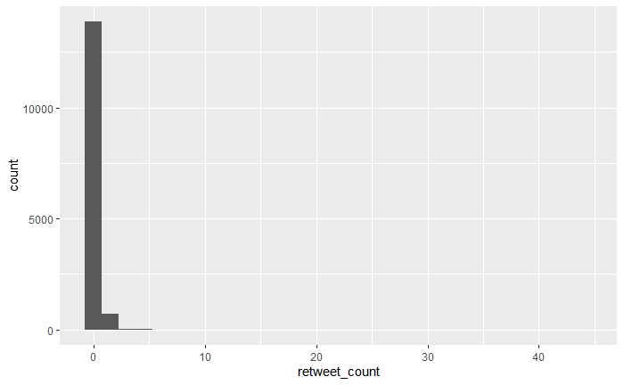

Mostly 0’s

## Cleaning text

Change to UTF-8 - Usually standard for internet text